# SF Calls for Service

Steven De La Fuente

9/20/2020

Introduction

This exploritory analysis is the first step toward achieving a larger project goal of improving theoretical availability and utilization rates of San Francisco Fire Department services. San Francisco faces many social challenges similar to other rapidly devoloping cities. Today socio-economic disparity has become evident in nearly every neighborhood of the city. Maintaing and improving departmental services may lead to future quality of life and resiliancy improvements among the cities most vulnerable populations.

Objective

Data

-Data Repository : https://datasf.org/opendata/ * Fire Department Calls for Service https://data.sfgov.org/Public-Safety/Fire-Department-Calls-for-Service/nuek-vuh3

```
* Analysis Neighborhoods Shapefile
https://data.sfgov.org/Geographic-Locations-and-Boundaries/Analysis-Neighborhoods/p5b7-5n3h
```

Packages used

- library(tidyr, ggplot2, dplyr, lubridate, stringr, sf)

San Francisco Fire Department, Calls for Service dataset.

```r
data <- read.csv(file= "Fire_Department_Calls_for_Service_2016.csv")
```

Shapefile deliniating neighborhood boundarys.

```r
sfn_shp <- st_read('analysis_neighborhoods/geo_export_5d44b28b-6636-490e-befb-b633d2e31944.shp')
```

-Analysis

```r
str(data)
```

```
## 'data.frame':    1331262 obs. of  33 variables:
##  $ Call.Number                         : int  160013921 160011748 160012684 160013992 160011403 160012952 160011742 160012467 160011634 160013438 ...
##  $ Unit.ID                             : Factor w/ 487 levels "47","49","50",..: 220 468 29 40 18 451 222 222 329 23 ...
##  $ Incident.Number                     : int  16000543 16000310 16000408 16000550 16000251 16000441 16000307 16000380 16000288 16000488 ...
##  $ Call.Date                           : Factor w/ 1556 levels "01/01/2016","01/01/2017",..: 1 1 1 1 1 1 1 1 1 1 ...
##  $ Watch.Date                          : Factor w/ 1558 levels "01/01/2016","01/01/2017",..: 1 1 1 1 1 1 1 1 1 1 ...
##  $ Received.DtTm                       : Factor w/ 631697 levels "01/01/2016 01:00:34 AM",..: 453 463 206 470 361 261 461 161 425 337 ...
##  $ Entry.DtTm                          : Factor w/ 631693 levels "01/01/2016 01:00:47 AM",..: 455 465 209 471 363 263 461 162 427 343 ...
##  $ Dispatch.DtTm                       : Factor w/ 753760 levels "01/01/2016 01:00:25 AM",..: 590 602 306 614 480 364 596 244 557 459 ...
##  $ Response.DtTm                       : Factor w/ 1281545 levels "","01/01/2016 01:00:24 AM",..: 975 999 476 1019 791 593 990 373 926 760 ...
##  $ On.Scene.DtTm                       : Factor w/ 1061848 levels "","01/01/2016 01:00:08 AM",..: 804 821 1 842 653 478 824 1 768 626 ...
##  $ Transport.DtTm                      : Factor w/ 378055 levels "","01/01/2016 01:00:45 AM",..: 1 1 1 1760 213 1 1 1 249 204 ...
##  $ Hospital.DtTm                       : Factor w/ 371607 levels "","01/01/2016 01:01:23 AM",..: 1 1 1 1732 213 1 1 1 244 192 ...
##  $ Call.Final.Disposition              : Factor w/ 15 levels "Against Medical Advice",..: 1 7 7 4 5 7 4 13 4 4 ...
##  $ Available.DtTm                      : Factor w/ 1271265 levels "","01/01/2016 01:00:18 AM",..: 1025 1019 510 6141 928 625 1002 382 990 828 ...
```

[output cut: 19 more lines]

```r
summary(data)
```

```
##   Call.Number           Unit.ID        Incident.Number
##  Min.   :160010009   E03    :  41761   Min.   :16000001
##  1st Qu.:170324036   E01    :  37249   1st Qu.:17014125
##  Median :180571937   E36    :  29030   Median :18024334
##  Mean   :178508992   T03    :  21725   Mean   :17748682
##  3rd Qu.:190852574   E07    :  19141   3rd Qu.:19036305
##  Max.   :200973188   E13    :  16936   Max.   :20041505
##                      (Other):1165420
##       Call.Date            Watch.Date
##  09/02/2017:   1741   09/01/2017:   1826
##  09/01/2017:   1725   09/02/2017:   1755
##  06/10/2019:   1414   06/10/2019:   1385
##  12/07/2019:   1208   12/31/2019:   1251
##  09/13/2019:   1202   09/13/2019:   1234
##  01/01/2016:   1194   10/24/2019:   1183
##  (Other)   :1322778   (Other)   :1322628
##                 Received.DtTm                      Entry.DtTm
##  06/18/2016 02:19:13 PM:     83   06/18/2016 02:19:40 PM:     83
##  03/17/2018 07:23:33 PM:     58   03/17/2018 07:23:46 PM:     58
##  06/16/2017 01:05:08 PM:     57   06/16/2017 01:05:47 PM:     57
##  02/29/2020 08:43:21 PM:     54   02/29/2020 08:45:01 PM:     54
##  02/06/2019 01:08:32 PM:     52   02/06/2019 01:08:32 PM:     52
##  10/20/2016 12:11:54 AM:     51   10/20/2016 12:13:12 AM:     51
##  (Other)               :1330907   (Other)               :1330907
##                 Dispatch.DtTm                    Response.DtTm
##  02/12/2017 08:32:56 AM:     19                         :  33308
##  02/27/2016 10:16:20 AM:     18   01/14/2018 05:04:46 AM:     14
##  03/21/2016 04:11:43 PM:     18   02/24/2017 12:04:50 PM:     14
##  04/30/2016 03:51:05 PM:     18   02/11/2017 08:39:56 AM:     12
##  08/10/2016 05:52:39 PM:     18   02/29/2020 08:59:29 PM:     10
##  03/23/2020 10:43:39 AM:     17   01/24/2016 05:47:06 AM:      9
##  (Other)               :1331154   (Other)               :1297895
##                 On.Scene.DtTm                    Transport.DtTm
##                        : 259789                         :952328
##  01/14/2018 05:04:46 AM:     14   01/10/2017 12:01:28 AM:     3
##  01/27/2019 03:12:21 AM:     13   02/10/2019 12:48:29 PM:     3
##  05/25/2019 08:59:00 AM:     12   03/26/2017 11:42:52 PM:     3
##  03/27/2018 12:02:07 AM:     10   03/27/2017 07:57:04 AM:     3
##  04/03/2017 05:10:50 PM:     10   04/06/2018 12:34:34 PM:     3
##  (Other)               :1071414   (Other)               :378919
```

[output cut: 57 more lines]

```
##  (37.786117211838, -122.419854245692):   5265
##  (37.777624238929, -122.39998111124) :   5120
##  (37.779531084663, -122.413542548681):   3213
##  (37.78114586126, -122.409026046516) :   3206
##  (37.78186544733, -122.414285346421) :   2958
##  (37.784807388677, -122.413615438263):   2887
##  (Other)                             :1308613
##              Neighborhooods...Analysis.Boundaries            RowID
##  Tenderloin                    :186622            160010009-KM06:      1
##  South of Market               :139740            160010009-KM11:      1
##  Mission                       :118544            160010013-63  :      1
##  Financial District/South Beach: 96272            160010015-E09 :      1
##  Bayview Hunters Point         : 68403            160010018-B08 :      1
##  Sunset/Parkside               : 47490            160010018-E18 :      1
##  (Other)                       :674191            (Other)       :1331256
```

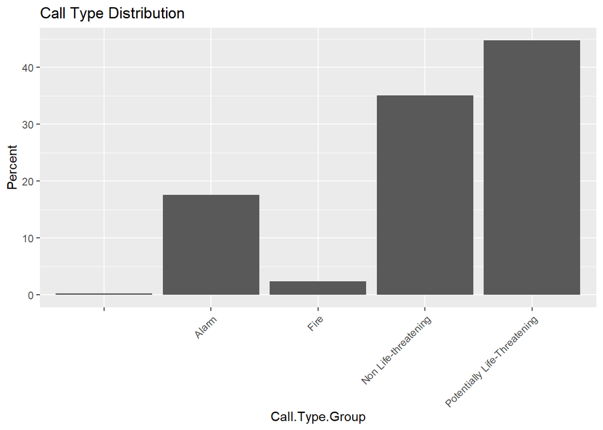

```r
call_type_distribution <- data %>%
  group_by(Call.Type.Group) %>%
  summarise(Percent =((n_distinct(Incident.Number)/
                         n_distinct(data$Incident.Number)*100)))
ggplot(data=call_type_distribution , aes(x=Call.Type.Group, y=Percent)) +
  geom_bar(stat="identity")+theme(axis.text.x = element_text(angle = 45,
                                                             hjust = 1)) +
  ggtitle("Call Type Distribution")
```

```r
head(call_type_distribution%>%arrange(desc(Percent)),10)
```

```
## Error in get(genname, envir = envir) : object 'vec_proxy' not found
## Error in get(genname, envir = envir) : object 'vec_ptype2' not found
## Error in get(genname, envir = envir) : object 'vec_proxy' not found
## Error in get(genname, envir = envir) : object 'vec_ptype2' not found
## # A tibble: 5 x 2
##   Call.Type.Group              Percent
##   <fct>                          <dbl>
## 1 Potentially Life-Threatening  44.8
## 2 Non Life-threatening          35.1
## 3 Alarm                         17.6
## 4 Fire                           2.34
## 5 ""                             0.233
```

Summary of total coll volume by neighborhood, decsending order. Neighborhoods near the city center experiance relativly higher call volumes when compaired to other areas of the city.

```r
Neiborhood_call_volume <- data%>%group_by(Neighborhooods...Analysis.Boundaries) %>%
 rename(nhood = Neighborhooods...Analysis.Boundaries) %>%
  summarise(count = n_distinct(Incident.Number))
Neiborhood_call_volume %>% arrange(desc(Neiborhood_call_volume$count)) %>% print(n=Inf)
```

```
## # A tibble: 42 x 2
##    nhood                          count
##    <fct>                          <int>
##  1 Tenderloin                     92105
##  2 South of Market                70131
##  3 Mission                        59660
##  4 Financial District/South Beach 45269
##  5 Bayview Hunters Point          32111
##  6 Sunset/Parkside                22917
##  7 Western Addition               22029
##  8 Nob Hill                       19725
##  9 Castro/Upper Market            17115
## 10 Hayes Valley                   15784
## 11 Outer Richmond                 14742
## 12 West of Twin Peaks             13527
```

[output cut: 30 more lines]

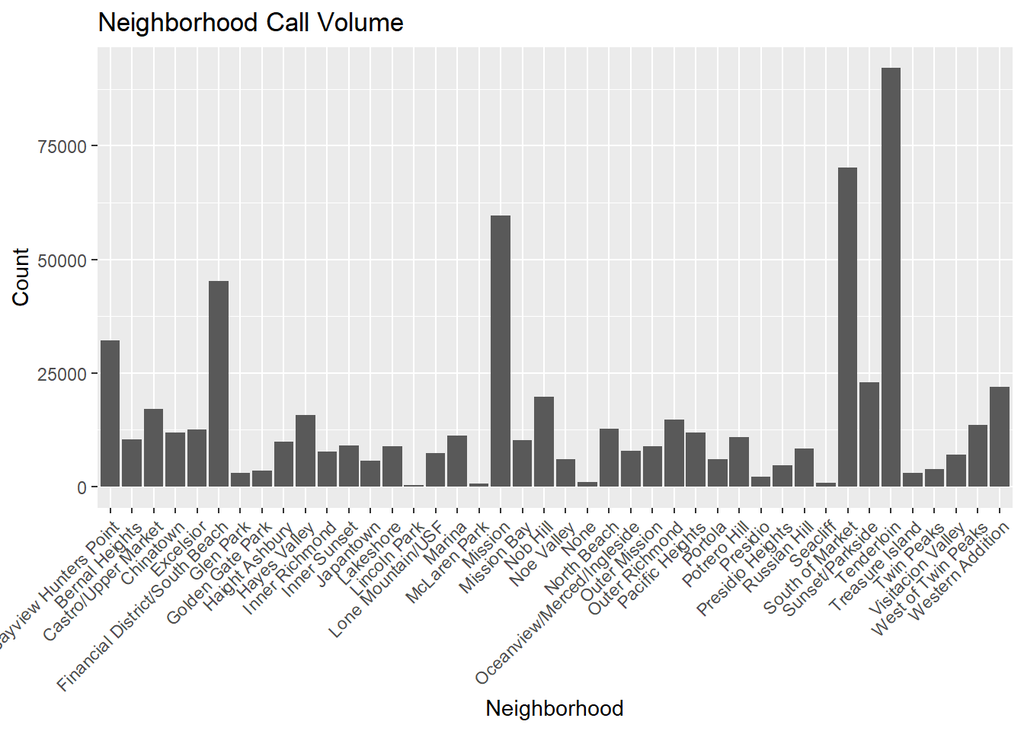

```r
Neiborhood_call_volume <- data%>%group_by(Neighborhooods...Analysis.Boundaries) %>%
 rename(nhood = Neighborhooods...Analysis.Boundaries) %>%
  summarise(count = n_distinct(Incident.Number))
ggplot(data=Neiborhood_call_volume ,
       aes(x=nhood , y=count)) +
  geom_bar(stat="identity")+theme(axis.text.x = element_text(angle = 45,
                                                             hjust = 1)) +
  ggtitle('Neighborhood Call Volume') +
  labs(x='Neighborhood', y = 'Count')
```

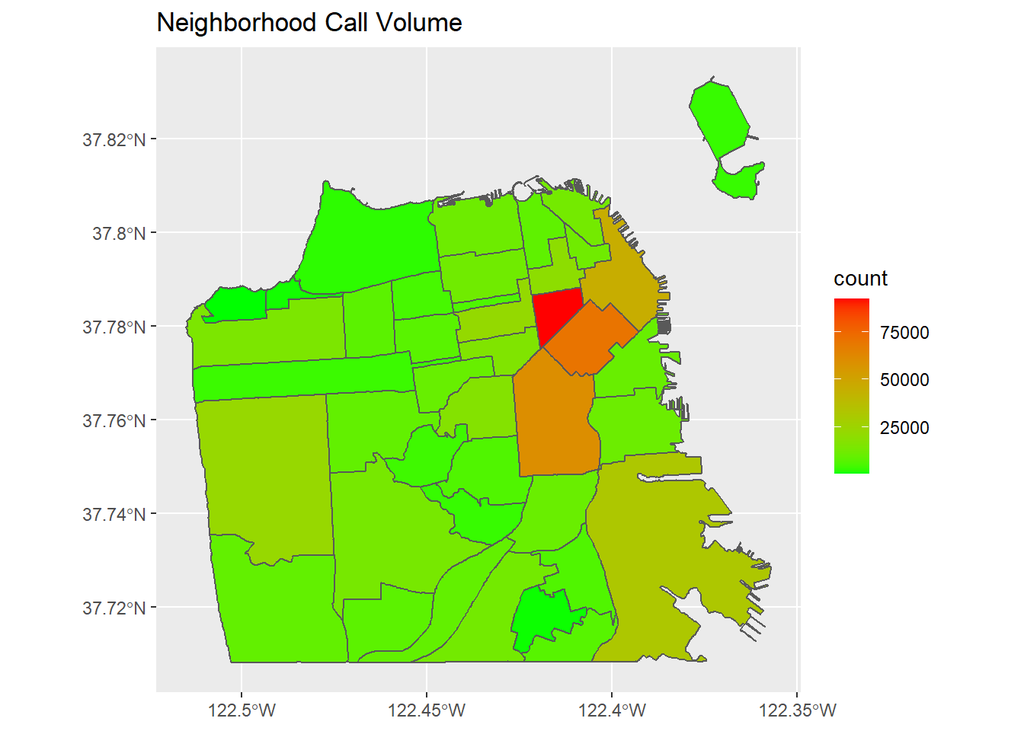

```r
neighborhood_call_shp <- inner_join(sfn_shp,Neiborhood_call_volume)
ggplot(neighborhood_call_shp) + geom_sf(aes(fill=count)) +
  scale_fill_gradient(low = 'green',high = 'red' )+
  ggtitle('Neighborhood Call Volume')
```

Downtown companies have consistanly ranked among the busiest in the Nation.

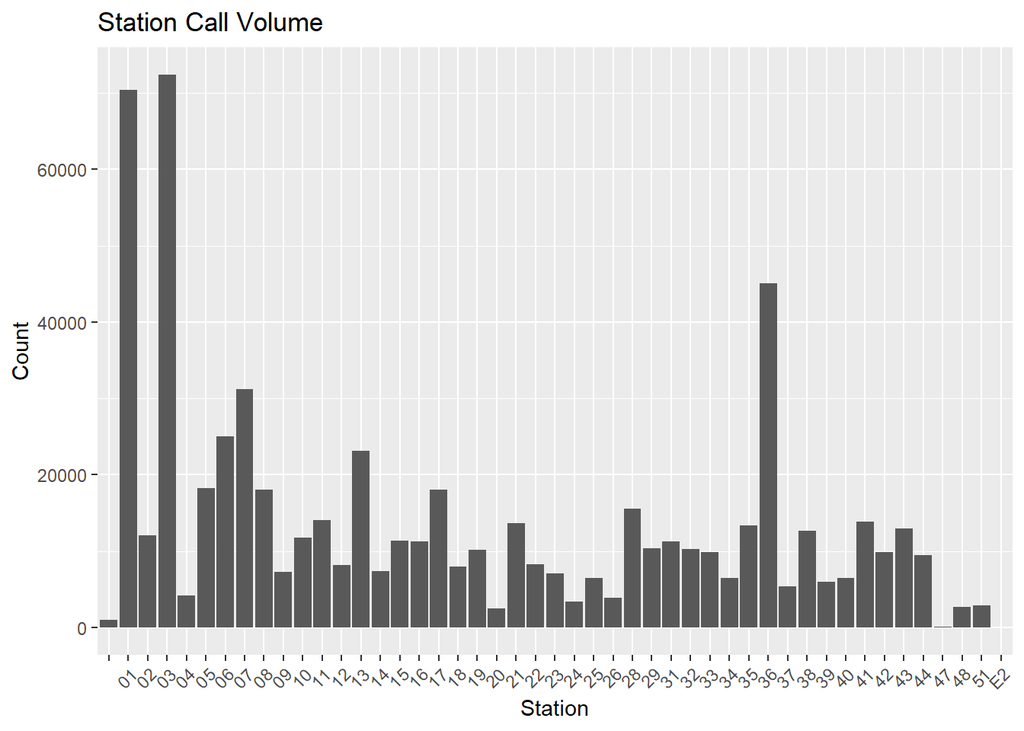

```r
station_call_volume <- data %>%
  group_by(Station.Area) %>%
  summarise(count = n_distinct(Incident.Number))
ggplot(data=station_call_volume , aes(x=Station.Area, y=count)) +
  geom_bar(stat="identity")+theme(axis.text.x = element_text(angle = 45,
                                                             hjust = 1)) +
  ggtitle('Station Call Volume') + labs(x = 'Station',y='Count')
```

Engine truck and Ambulance companies form the main response contingency of the department. These units contain a diverse set of tools and capabilities, requiring specialized training. Many departmental members are cross trained and are capable of preforming essential duties on any unit.

Engine companies respond to almost every type of emergency, provide basic and advanced medical care and are typicly assisgned to fire attack operations.

Truck companies are the largest fire department apparatus, cary a vast array of specialised forcible entry tools and a large assortment of ladders needed to preform search and rescue operations.

Ambulance or “Medic” companies are staffed with paramedics and provide medical care and transport.

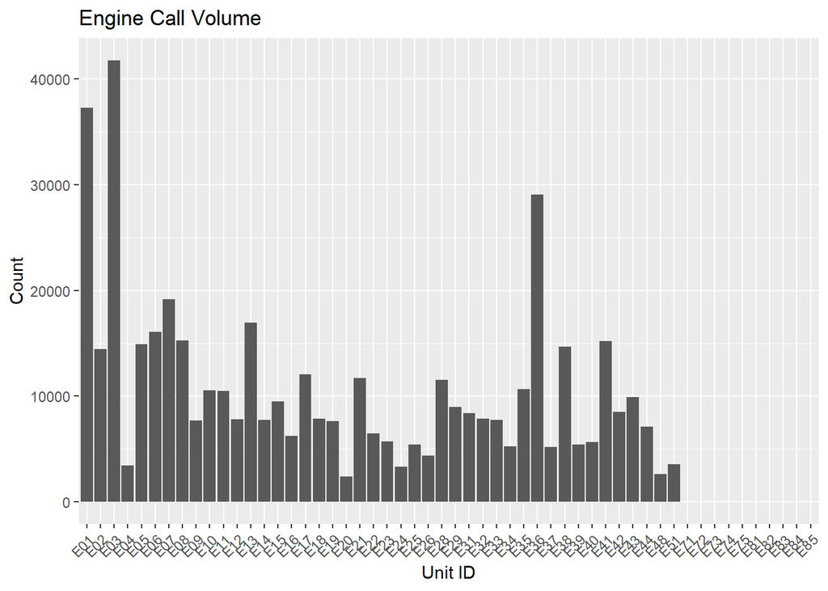

```r
engine_call_volume <- data %>% filter(Unit.Type == 'ENGINE') %>%
  group_by(Unit.ID) %>%
  summarise(count = n_distinct(Incident.Number))
ggplot(data=engine_call_volume , aes(x=Unit.ID, y=count)) +
  geom_bar(stat="identity")+theme(axis.text.x = element_text(angle = 45,
                                                             hjust = 1)) +
  ggtitle('Engine Call Volume') + labs(x= 'Unit ID', y='Count')
```

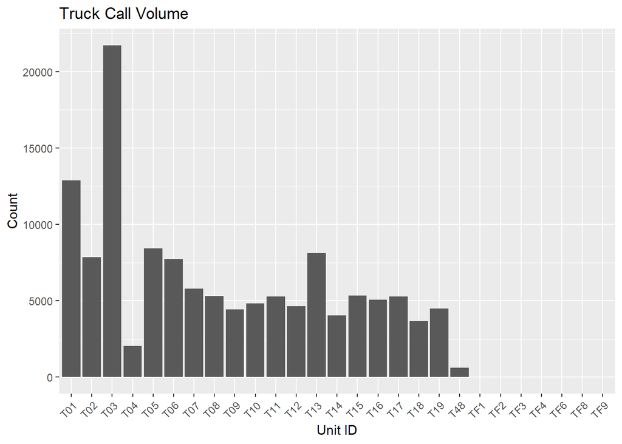

```r
truck_call_volume <- data %>% filter(Unit.Type == 'TRUCK') %>%
  group_by(Unit.ID) %>%
  summarise(count = n_distinct(Incident.Number))
ggplot(data=truck_call_volume , aes(x=Unit.ID, y=count)) +
  geom_bar(stat="identity")+theme(axis.text.x = element_text(angle = 45,
                                                             hjust = 1)) +
  ggtitle("Truck Call Volume") + labs(x= 'Unit ID', y='Count')
```

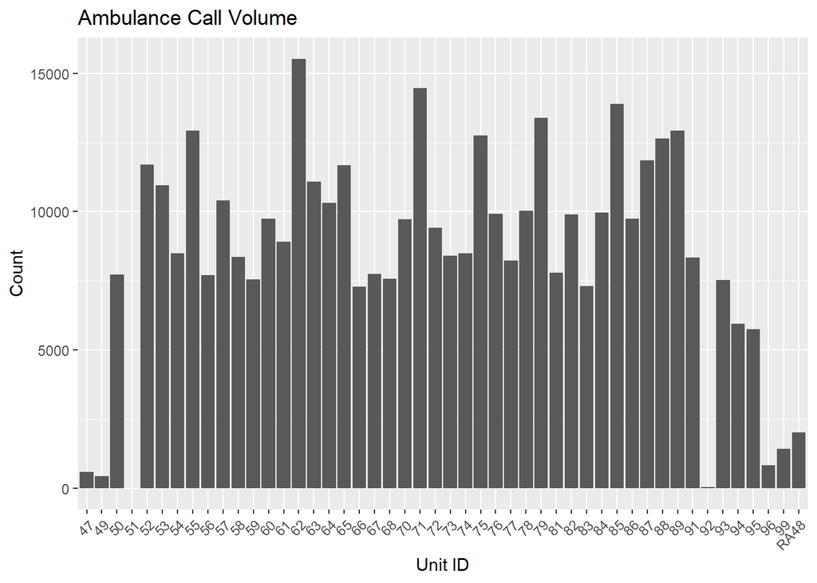

```r
medic_call_volume <- data %>% filter(Unit.Type == 'MEDIC') %>%
  group_by(Unit.ID) %>%
  summarise(count = n_distinct(Incident.Number))
ggplot(data=medic_call_volume , aes(x=Unit.ID, y=count)) +
  geom_bar(stat="identity")+theme(axis.text.x = element_text(angle = 45,
                                                             hjust = 1)) +
  ggtitle("Ambulance Call Volume") + labs(x= 'Unit ID', y='Count')
```

```r
fire_volume <- data %>% rename(nhood = Neighborhooods...Analysis.Boundaries) %>%
  filter(data$Call.Type.Group == 'Fire') %>% group_by(nhood) %>%
  summarise(count = n_distinct(Incident.Number))
fire_volume_shp <- inner_join(sfn_shp,fire_volume)
```

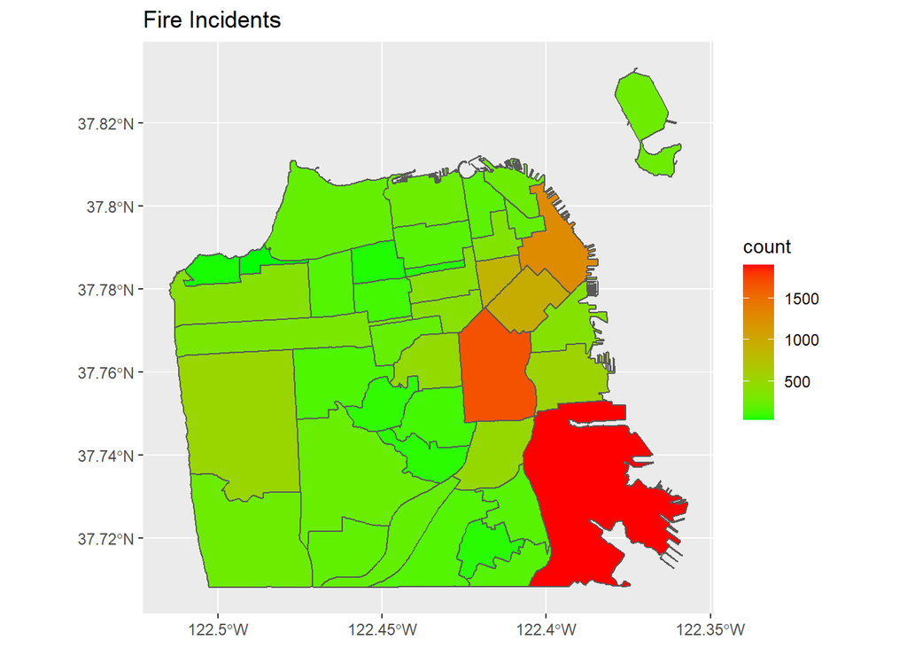

```r
ggplot(fire_volume_shp) + geom_sf(aes(fill=count)) +
  scale_fill_gradient(low = 'green',high = 'red' )+
  ggtitle('Fire Incidents')
```

```r
medical_volume <- data %>% rename(nhood = Neighborhooods...Analysis.Boundaries) %>%
  filter(data$Call.Type == 'Potentially Life-Threatening') %>% group_by(nhood) %>%
  summarise(count = n_distinct(Incident.Number))

medical_volume_shp <- inner_join(sfn_shp,medical_volume)
```

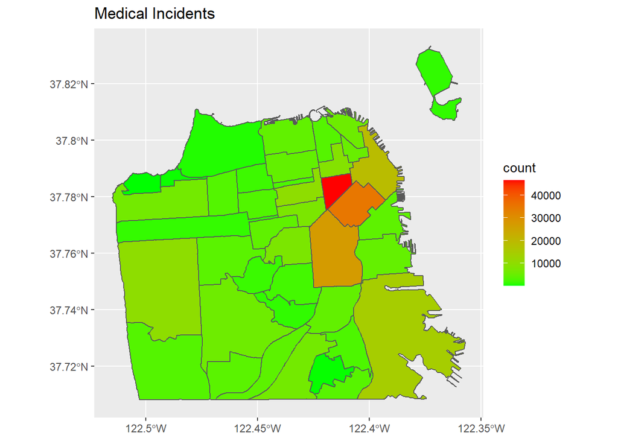

```r
ggplot(medical_volume_shp) + geom_sf(aes(fill=count)) +
  scale_fill_gradient(low = 'green',high = 'red' )+
  ggtitle('Medical Incidents')
```

```r
data <- separate(data, Location, into = c("long", "lat"), sep = ",")
data$lat <- str_remove_all(data$lat,'[)]') %>% as.numeric(data$lat)
data$long <- str_remove_all(data$long,'[(]') %>% as.numeric(data$long)
data$Received.DtTm <- parse_date_time(data$Received.DtTm, '%m/%d/%Y %I:%M:%S %p')
data$Entry.DtTm <- parse_date_time(data$Entry.DtTm, '%m/%d/%Y %I:%M:%S %p')
data$Dispatch.DtTm <- parse_date_time(data$Dispatch.DtTm, '%m/%d/%Y %I:%M:%S %p')
data$Response.DtTm <- parse_date_time(data$Response.DtTm, '%m/%d/%Y %I:%M:%S %p')
data$On.Scene.DtTm <- parse_date_time(data$On.Scene.DtTm, '%m/%d/%Y %I:%M:%S %p')
data$Transport.DtTm <- parse_date_time(data$Transport.DtTm, '%m/%d/%Y %I:%M:%S %p')
data$Hospital.DtTm <- parse_date_time(data$Hospital.DtTm, '%m/%d/%Y %I:%M:%S %p')
data$Available.DtTm <- parse_date_time(data$Available.DtTm, '%m/%d/%Y %I:%M:%S %p')
data$disp_response_delta <- as.difftime(data$Response.DtTm - data$Dispatch.DtTm)
code3_response_time <- data %>%
  rename(nhood = Neighborhooods...Analysis.Boundaries) %>%
  filter(data$Priority == '3') %>% na.omit(code3_response_time$On.Scene.DtTm)
code3_response_time$response_time <- as.numeric(difftime(code3_response_time$On.Scene.DtTm,
                                              code3_response_time$Response.DtTm),
                                              units = 'mins')
code3_response_time$hour <- hour(code3_response_time$Dispatch.DtTm)
calls_by_hour <- code3_response_time %>% group_by(hour)%>%
  summarise(count = n_distinct(Incident.Number))
```

Call volume increases during the dayight hours and is consistant with a increased daytime population comprised of many outside workers.

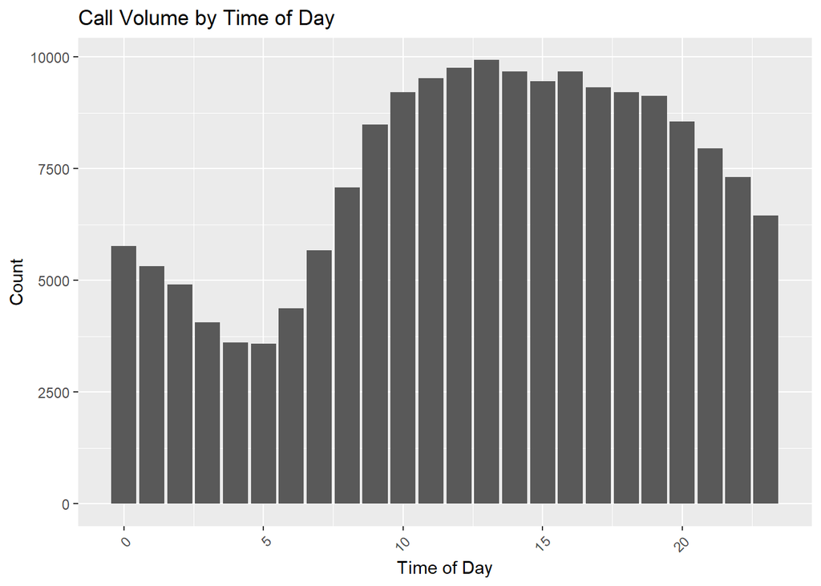

```r
ggplot(data=calls_by_hour , aes(x=hour, y=count)) +
  geom_bar(stat="identity")+
  theme(axis.text.x = element_text(angle = 45, hjust = 1)) +
  ggtitle("Call Volume by Time of Day") + labs(x= 'Time of Day', y='Count')
```

```r
TOD_response_time <- code3_response_time %>%
  mutate(TOD = hour(code3_response_time$Dispatch.DtTm)) %>%
  group_by(TOD) %>%
  summarise(count = mean(response_time))
scatter.smooth(TOD_response_time$TOD,TOD_response_time$count,
main ='Average Response Time', ylab= 'Response Time (Minutes)', xlab= 'Time of Day')
```

[figure not shown]

All engine companies in San Francisco can provide Basic Life Support (BLS) services and selected companies are staffed with Paramedics, providing Advanced Life Support (ALS) services.

As we can see below, average BLS response times are extremely low, averaging around 2.5 minutes. ALS engine companies are dynamicly staffed throughout the city, on a daily basis. This allows fast response from a designated location. ALS engine companies are generally assisgned a greater coverage area, witch may be the for increased average response times.

Through this dynamic coverage system the department is able to provide much needed medical services while awaiting the arrival of a transport ambulance.

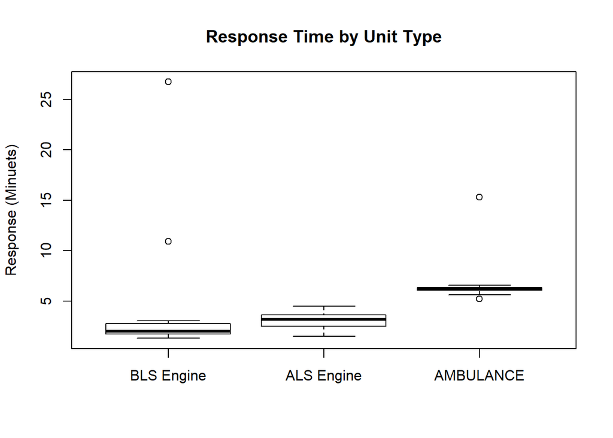

```r
engine_ALS_medical_response_time <- code3_response_time %>%
  filter(code3_response_time$Call.Type == 'Potentially Life-Threatening' &
           code3_response_time$Unit.Type == 'ENGINE' &
           code3_response_time$ALS.Unit == 'true') %>%
  group_by(Station.Area) %>%
  summarise(count = mean(response_time))
engine_ALS_outliers <- boxplot(engine_ALS_medical_response_time, plot=FALSE)$out
engine_ALS_medical_response_time_clean <-
  engine_ALS_medical_response_time[-which(engine_ALS_medical_response_time$count
                                          %in% engine_ALS_outliers),]
engine_BLS_medical_response_time <- code3_response_time %>%
  filter(code3_response_time$Call.Type == 'Potentially Life-Threatening' &
           code3_response_time$Unit.Type == 'ENGINE' &
           code3_response_time$ALS.Unit == 'false') %>%
  group_by(Station.Area) %>%
  summarise(count = mean(response_time))
medic_response_time <- code3_response_time %>%
  filter(code3_response_time$Unit.Type == 'MEDIC' &
           code3_response_time$Call.Type == 'Potentially Life-Threatening') %>%
  group_by(Unit.ID) %>%
  summarise(count = mean(response_time))
boxplot(engine_BLS_medical_response_time$count,
        engine_ALS_medical_response_time_clean$count,
        medic_response_time$count,
        names = c('BLS Engine','ALS Engine','AMBULANCE'),
        main = 'Response Time by Unit Type',
        ylab = 'Response (Minuets)')
```

As we can see below, ambulance response times are shortest in the geographic regions where ther tends to be a greater call volume.

```r
medic_response_time_shape_prep <- code3_response_time %>%
  filter(code3_response_time$Unit.Type == 'MEDIC' &
           code3_response_time$Call.Type == 'Potentially Life-Threatening') %>%
  group_by(nhood) %>%
  summarise(Minutes = mean(response_time))
medic_response_shp <- inner_join(sfn_shp,medic_response_time_shape_prep)
```

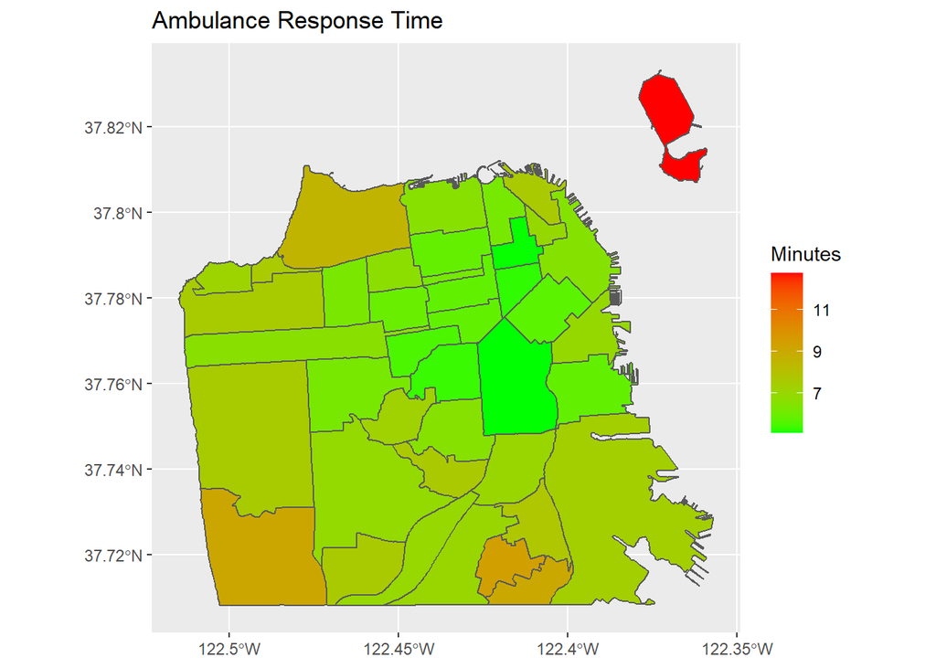

```r
ggplot(medic_response_shp) + geom_sf(aes(fill=Minutes)) +
  scale_fill_gradient(low = 'green',high = 'red' )+
  ggtitle('Ambulance Response Time')
```

Conclusion

San Francisco Fire Deparments has built a system that can easily adapt to the required system load; The amazing men and women that comprise the department will continue to make advances toward improving departmental services.

Further investigation into incident location and desity using traditionaal rasterization methods may be usefull in preforming prdictive analytics over space and time; Making further improvements to dynamic ambulace deployment and response.

Socio-economic factors should also be used in futher analysis. Finding locations that would most benifit from improved community clinincs and social services may decreasing system load by providing neighborhood medical care; imporoving emergent response times while also improveing overall community health.